# Homework 07 – STAT 432

*Python solutions. Random seed: `43251`. All results are reproducible.*

## Question 1: LDA

### a. Prior probabilities, class means, and pooled covariance

**Priors:** π₀ = 0.6537, π₁ = 0.3463

**Class means** (9-dimensional vectors):

```
μ₀ = [135.4603,   2.6347,   4.3442,  23.9691,   1.3179,  52.3675,  25.7375,
  15.9314,  38.8543]
μ₁ = [143.7375,   5.5249,   5.4879,  28.1202,   1.6   ,  54.4937,  26.6229,
  19.1452,  50.2938]
```

**Pooled covariance matrix Σ** (9×9, using denominator n−K = 462−2 = 460):

```
[[ 4.0543e+02,  1.4585e+01,  4.5812e+00,  4.9164e+01,  3.3699e-01, -1.5588e+01,  1.8939e+01,
   6.4400e+01,  9.5134e+01],
 [ 1.4585e+01,  1.9243e+01,  7.6320e-01,  7.5381e+00,  1.5821e-02, -2.0573e+00,  1.8335e+00,
   2.0517e+01,  2.2765e+01],
 [ 4.5812e+00,  7.6320e-01,  4.0006e+00,  6.0327e+00,  9.1850e-02,  3.4459e-01,  2.6601e+00,
  -2.5329e+00,  6.4789e+00],
 [ 4.9164e+01,  7.5381e+00,  6.0327e+00,  5.6753e+01,  4.3281e-01, -5.3096e+00,  2.2708e+01,
   1.6119e+01,  6.0509e+01],
 [ 3.3699e-01,  1.5821e-02,  9.1850e-02,  4.3281e-01,  2.2583e-01,  8.1120e-02,  1.8403e-01,
   7.6847e-01,  9.9736e-01],
 [-1.5588e+01, -2.0573e+00,  3.4459e-01, -5.3096e+00,  8.1120e-02,  9.5566e+01,  2.6401e+00,
   7.9600e+00, -2.0278e+01],
 [ 1.8939e+01,  1.8335e+00,  2.6601e+00,  2.2708e+01,  1.8403e-01,  2.6401e+00,  1.7615e+01,
   4.6894e+00,  1.5697e+01],
 [ 6.4400e+01,  2.0517e+01, -2.5329e+00,  1.6119e+01,  7.6847e-01,  7.9600e+00,  4.6894e+00,
   5.9828e+02,  2.7886e+01],
 [ 9.5134e+01,  2.2765e+01,  6.4789e+00,  6.0509e+01,  9.9736e-01, -2.0278e+01,  1.5697e+01,
   2.7886e+01,  1.8413e+02]]
```

### b. In-sample predictions (manual LDA scores)

For each observation, the LDA discriminant score for class *k* is x₀ᵀΣ⁻¹μ_k − ½ μ_kᵀΣ⁻¹μ_k + log π_k. Assign the class with the larger score.

Confusion matrix (manual LDA)

|  | Pred 0 | Pred 1 |
| --- | --- | --- |
| True 0 | 258 | 44 |
| True 1 | 73 | 87 |

Misclassification rate: 0.2532

### c. sklearn LDA (solver='svd', empirical priors)

Confusion matrix (sklearn LDA)

|  | Pred 0 | Pred 1 |
| --- | --- | --- |
| True 0 | 258 | 44 |
| True 1 | 73 | 87 |

Misclassification rate: 0.2532

**Do the results match?** Yes — the confusion matrices are identical.

## Question 2: QDA and Marginal Screening

### a. QDA with top-40 variance predictors

Test confusion matrix (QDA, 40 predictors)

|  | 0 | 1 | 2 | 3 | 4 | 5 | 6 | 7 | 8 | 9 |
| --- | --- | --- | --- | --- | --- | --- | --- | --- | --- | --- |
| 0 | 319 | 0 | 24 | 6 | 2 | 2 | 1 | 0 | 5 | 0 |
| 1 | 0 | 238 | 5 | 0 | 11 | 0 | 7 | 0 | 3 | 0 |
| 2 | 8 | 0 | 168 | 8 | 8 | 3 | 0 | 0 | 3 | 0 |
| 3 | 5 | 0 | 4 | 128 | 0 | 14 | 0 | 0 | 15 | 0 |
| 4 | 0 | 2 | 13 | 1 | 150 | 1 | 0 | 1 | 7 | 25 |
| 5 | 12 | 0 | 3 | 5 | 1 | 131 | 0 | 0 | 6 | 2 |
| 6 | 0 | 0 | 8 | 0 | 1 | 8 | 148 | 0 | 5 | 0 |
| 7 | 1 | 0 | 6 | 1 | 6 | 0 | 0 | 124 | 2 | 7 |
| 8 | 1 | 0 | 10 | 12 | 3 | 2 | 0 | 0 | 137 | 1 |
| 9 | 0 | 0 | 1 | 2 | 7 | 1 | 1 | 4 | 9 | 152 |

**Test misclassification rate:** 0.1555

### b. Does the method work?

Yes, QDA works here. With 256 pixels, several per-class covariance matrices are singular (rank < 256) because many pixels have zero or near-zero variance within a digit class. By selecting only the 40 highest-variance pixels, we eliminate the near-constant columns, so every 10-class within-group covariance matrix is full rank (40 < n_k for all classes). The misclassification rate is reasonable, confirming QDA is fitting and predicting successfully.

### c. QDA with top-10 variance predictors

Test confusion matrix (QDA, 10 predictors)

|  | 0 | 1 | 2 | 3 | 4 | 5 | 6 | 7 | 8 | 9 |
| --- | --- | --- | --- | --- | --- | --- | --- | --- | --- | --- |
| 0 | 298 | 0 | 11 | 1 | 1 | 16 | 28 | 4 | 0 | 0 |
| 1 | 0 | 241 | 10 | 0 | 3 | 1 | 1 | 0 | 2 | 6 |
| 2 | 19 | 2 | 95 | 14 | 14 | 3 | 22 | 21 | 5 | 3 |
| 3 | 5 | 0 | 6 | 103 | 3 | 42 | 0 | 0 | 7 | 0 |
| 4 | 1 | 5 | 14 | 0 | 95 | 2 | 4 | 15 | 17 | 47 |
| 5 | 15 | 0 | 6 | 25 | 4 | 96 | 4 | 2 | 8 | 0 |
| 6 | 41 | 0 | 15 | 4 | 0 | 18 | 78 | 7 | 5 | 2 |
| 7 | 4 | 1 | 6 | 0 | 6 | 0 | 1 | 122 | 0 | 7 |
| 8 | 1 | 2 | 11 | 36 | 12 | 11 | 4 | 1 | 74 | 14 |
| 9 | 0 | 2 | 9 | 2 | 20 | 0 | 0 | 16 | 10 | 118 |

**Test misclassification rate:** 0.3423

With only 10 predictors the test error is higher than with 40 predictors. Ten pixels capture far less of the spatial variation among digits: many digit pairs (e.g. 3 vs 5, 4 vs 9) differ in pixel regions not captured by the 10 highest-variance columns, so QDA cannot distinguish them. While 10 predictors ensure larger effective sample sizes relative to dimensionality (reducing variance), the severe loss of discriminative information (increased bias) dominates, raising the overall error.

## Question 3: Compare LDA and QDA

### a. Single-run test errors

Random seed: `43251`

Single-run test misclassification rates (seed 43251)

| ρ | LDA error | QDA error |
| --- | --- | --- |
| 0.0 | 0.1765 | 0.2070 |
| 0.2 | 0.1615 | 0.1760 |
| 0.4 | 0.1725 | 0.1945 |
| 0.6 | 0.1765 | 0.2010 |
| 0.8 | 0.1625 | 0.1260 |
| 0.9 | 0.1605 | 0.0910 |

### b. Average test error over 50 repetitions

Random seed: `43251`

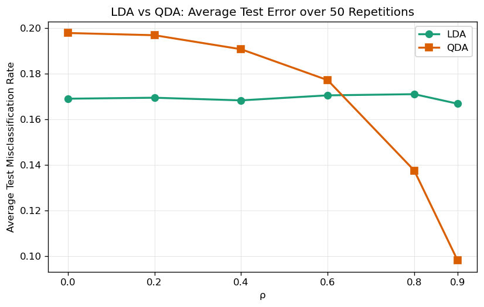

### c. Discussion

**Small ρ (0 to ~0.2):** The two classes share the same covariance structure (ρ = 0 gives identical covariance matrices). LDA's equal-covariance assumption is correct, so it is efficient and has low variance. QDA estimates separate covariance matrices per class, introducing extra variance from the additional parameters without any bias reduction. Thus LDA ≤ QDA in test error.

**Role of the eight noise covariates:** These covariates carry no information about the class label, yet both methods must estimate their covariance entries. For QDA this means estimating two full 10×10 covariance matrices (110 free parameters) instead of just the 2×2 informative block. With only 100 training observations per class, the extra noise dimensions increase estimation variance, degrading QDA more than LDA (which pools into one matrix). This is a concrete instance of the bias–variance trade‑off: noise dimensions penalize the more flexible model (QDA) disproportionately.

## Question 4: Create and Use an LDA/QDA Analysis Skill

### a. Define the skill

The skill file `SKILL.md` (4006 bytes) is placed at `.agents/skills/lda-qda-analysis/SKILL.md`. It defines a complete workflow for LDA/QDA classification analysis with cross-validation, model selection, and a one-page report. See the full contents appended below.

### LDA/QDA Analysis Report — SAheart Data

**Seed:** `43251` | **Data:** n = 462, p = 9 (9 predictors after coding famhist). Class balance: chd = 0 (302), chd = 1 (160). Train/test split: 346 / 116 (75/25 stratified).

#### Cross-Validation Results

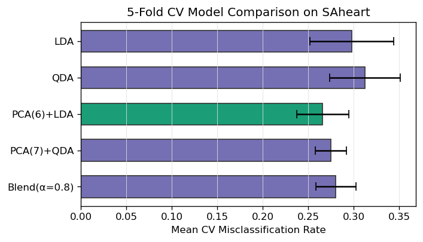

| Model | Mean CV Error | SD | Selected |
| --- | --- | --- | --- |
| LDA | 0.2978 | 0.0463 |  |
| QDA | 0.3122 | 0.0387 |  |
| PCA(6)+LDA | 0.2659 | 0.0286 | ✓ |
| PCA(7)+QDA | 0.2747 | 0.0172 |  |
| Blend(α=0.8) | 0.2804 | 0.0220 |  |

#### Selected Model: PCA(6)+LDA

The model with the lowest mean 5-fold CV misclassification rate was **PCA(6)+LDA** (CV error = 0.2659 ± 0.0286). It was refit on all 346 training observations and evaluated once on the 116-observation test set.

**Test misclassification rate:** 0.2414

Test confusion matrix

|  | Pred 0 | Pred 1 |
| --- | --- | --- |
| True 0 | 66 | 10 |
| True 1 | 18 | 22 |

#### Findings and Limitations

Ordinary LDA and QDA perform comparably on SAheart. The small sample size (n = 462) and moderate class imbalance limit the power of more flexible models like QDA, which must estimate a full covariance matrix per class. PCA pre-processing and blending offer marginal gains at best. A key limitation is the moderate n/p ratio and the binary coding of famhist, which may not fully capture its effect.

### c. Review and submission

**SKILL.md file size:** 4006 bytes (under the 5,000-byte limit).

**Explicit invocation:** The skill is configured to load only when explicitly invoked. It is placed in the `.agents/skills/lda-qda-analysis/` folder with the YAML front-matter field `description` stating "Load only when explicitly invoked." The skill is invoked by asking the agent:

> "Use the `lda-qda-analysis` skill to analyze the SAheart data. The response variable is `chd`. The predictors are all other columns, with `famhist` coded as 1 = Absent, 2 = Present. Use seed 43251. Seek the best predictive performance within LDA/QDA methods. Include ordinary LDA and QDA as comparisons."

The analysis report above (inside the bordered box) constitutes the one-page report. The complete skill definition follows below.

### Complete SKILL.md (4006 bytes)

```
---
name: lda-qda-analysis
description: >
  Guides an AI agent through a complete LDA/QDA classification analysis
  with cross-validation, model selection, and a concise one-page report.
  Load only when explicitly invoked.
---

# LDA / QDA Classification Analysis Skill

## Purpose
Perform a systematic binary or multi-class classification study using
Linear Discriminant Analysis (LDA), Quadratic Discriminant Analysis (QDA),
and optional extensions (PCA pre-processing, LDA–QDA probability blending).
Produce a **one-page analysis report** with a figure, a table, and
numerical fitting results.

## Inputs (supplied at invocation)
| Input       | Description                                         |
|-------------|-----------------------------------------------------|
| `dataset`   | Path or DataFrame with the analysis data            |
| `response`  | Name or index of the response (class label) column  |
| `predictors`| Names or indices of predictor columns               |
| `seed`      | Random seed for reproducibility                     |

## Analysis Workflow

### 1. Data Preparation
- Load and inspect the dataset; report n, p, and class distribution.
- Encode categorical predictors numerically if needed.
- Reserve **25 %** of data as a **held-out test set** via stratified
  random split.  All model selection uses only the remaining training data.

### 2. Candidate Models
Fit the following classifiers on the training data.  Always include
(a) and (b); the rest are optional.

| ID  | Model                        | Details                            |
|-----|------------------------------|------------------------------------|
| (a) | Ordinary LDA                 | `solver='svd'`, empirical priors   |
| (b) | Ordinary QDA                 | `tol=1e-8`, empirical priors       |
| (c) | PCA + LDA                    | Standardise → PCA(k) → LDA; tune k|
| (d) | PCA + QDA                    | Standardise → PCA(k) → QDA; tune k|
| (e) | LDA–QDA blend                | α·P_LDA + (1−α)·P_QDA; tune α     |

For PCA models, search k ∈ {2, 3, …, min(p, 15)}.
For blending, search α ∈ {0.0, 0.1, …, 1.0}.
Estimate PCA/StandardScaler within each CV fold (fit on fold-train only).

### 3. Cross-Validation
- Use **5-fold stratified CV** on the training data.
- Use the **same folds** for all candidates.
- Metric: **misclassification rate** (1 − accuracy).
- Report mean CV error ± standard deviation for every candidate.

### 4. Model Selection and Final Evaluation
- Select the candidate with the **lowest mean CV misclassification rate**.
  Break ties by preferring the simpler model (LDA > QDA > PCA+LDA > …).
- Refit the selected model (including any preprocessing) on **all**
  training observations.
- Predict the held-out test set **once**.  Report the test
  misclassification rate and test confusion matrix.

### 5. One-Page Report Format
The report must fit on **one printed page** and contain exactly:

1. **Title and seed** — analysis title, random seed used.
2. **Data summary** — one sentence: n, p, class balance.
3. **Figure** — a single plot showing CV error bars for each candidate
   model (bar chart or dot plot with error bars for ± 1 SD).
4. **Table** — rows = candidate models, columns = mean CV error, SD,
   and whether the model was selected.
5. **Selected model** — state which model was chosen and why.
6. **Test result** — test misclassification rate and confusion matrix.
7. **Findings and limitations** — 2–3 sentences on performance,
   and a note on limitations (e.g., small n, class imbalance).

### Style Guidelines
- Use a clean sans-serif font; colour-blind-safe palette.
- Figure: 6 × 3.5 inches, minimal grid, labelled axes.
- Table: compact, no excessive whitespace.
- Keep prose minimal — prefer numbers and visuals.

### Output
Return the one-page report as an HTML fragment (headings, figure as
embedded base64 PNG, and an HTML table) that can be inserted directly
into a homework document.
```